# Airline Passengers Satisfaction

Gabriele Fulcheri

2023-05-13

## INTRODUCTION

**How can we increase the satisfaction of our customers?**

The aim of this project is to analyze airline passengers’judgements in order to understand which are the main drivers of their satisfaction. Once these drivers are pointed out, it would be possible to design *ad hoc* recommendations on how to increase customers’satisfaction.

In order to perform this task, it is necessary to analyze the impact the various aspect of the service have on satisfaction, namely the impact a series of scalar values has on a qualitative data (satisfied vs neutral or dissatisfied). To perform such analysis, ANOVA and contingency tables will be the main focus of this project.

However, since the satisfaction’s drivers are 14 and passengers are organized in macro categories such as Loyal/Disloyal and Business/Personal Travellers, it will be necessary to reduce the complexity of the items and find more specific clusters where to perform *ad hoc* initiatives. ANOVA and Contingency tables will be therefore applied and sustained by EFA and Cluster Analysis on the factors obtained.

## DATA PREPARATION AND CLEANING

# Libraries used

```r
library(prettydoc)
library(writexl)
library(tidyverse)
library(readr)
library(scales)
library(psych)
library(effectsize)
library(rstatix)
library(nFactors)
library(factoextra)
```

# DATA LOADING AND CLEANING: a first glimpse at the data

```r
train <- read.csv('train.csv',header=TRUE, sep=',')
head(train)
```

```
##   X     id Gender     Customer.Type Age  Type.of.Travel    Class
## 1 0  70172   Male    Loyal Customer  13 Personal Travel Eco Plus
## 2 1   5047   Male disloyal Customer  25 Business travel Business
## 3 2 110028 Female    Loyal Customer  26 Business travel Business
## 4 3  24026 Female    Loyal Customer  25 Business travel Business
## 5 4 119299   Male    Loyal Customer  61 Business travel Business
## 6 5 111157 Female    Loyal Customer  26 Personal Travel      Eco
##   Flight.Distance Inflight.wifi.service Departure.Arrival.time.convenient
## 1             460                     3                                 4
## 2             235                     3                                 2
## 3            1142                     2                                 2
## 4             562                     2                                 5
## 5             214                     3                                 3
## 6            1180                     3                                 4
##   Ease.of.Online.booking Gate.location Food.and.drink Online.boarding
```

[output cut: 27 more lines]

As we can see, the dataset is organized with “ID” as a primary key and identifier of unique entries, while passengers in general are categorized by type of flight, gender, flight class, loyalty and satisfaction. Let’s have a glimpse of the values distribution:

```r
summary(train)
```

```
##        X                id            Gender          Customer.Type
##  Min.   :     0   Min.   :     1   Length:103904      Length:103904
##  1st Qu.: 25976   1st Qu.: 32534   Class :character   Class :character
##  Median : 51952   Median : 64857   Mode  :character   Mode  :character
##  Mean   : 51952   Mean   : 64924
##  3rd Qu.: 77927   3rd Qu.: 97368
##  Max.   :103903   Max.   :129880
##
##       Age        Type.of.Travel        Class           Flight.Distance
##  Min.   : 7.00   Length:103904      Length:103904      Min.   :  31
##  1st Qu.:27.00   Class :character   Class :character   1st Qu.: 414
##  Median :40.00   Mode  :character   Mode  :character   Median : 843
##  Mean   :39.38                                         Mean   :1189
##  3rd Qu.:51.00                                         3rd Qu.:1743
##  Max.   :85.00                                         Max.   :4983
##
##  Inflight.wifi.service Departure.Arrival.time.convenient Ease.of.Online.booking
##  Min.   :0.00          Min.   :0.00                      Min.   :0.000
##  1st Qu.:2.00          1st Qu.:2.00                      1st Qu.:2.000
##  Median :3.00          Median :3.00                      Median :3.000
##  Mean   :2.73          Mean   :3.06                      Mean   :2.757
##  3rd Qu.:4.00          3rd Qu.:4.00                      3rd Qu.:4.000
##  Max.   :5.00          Max.   :5.00                      Max.   :5.000
##
##  Gate.location   Food.and.drink  Online.boarding  Seat.comfort
##  Min.   :0.000   Min.   :0.000   Min.   :0.00    Min.   :0.000
##  1st Qu.:2.000   1st Qu.:2.000   1st Qu.:2.00    1st Qu.:2.000
##  Median :3.000   Median :3.000   Median :3.00    Median :4.000
##  Mean   :2.977   Mean   :3.202   Mean   :3.25    Mean   :3.439
##  3rd Qu.:4.000   3rd Qu.:4.000   3rd Qu.:4.00    3rd Qu.:5.000
##  Max.   :5.000   Max.   :5.000   Max.   :5.00    Max.   :5.000
##
##  Inflight.entertainment On.board.service Leg.room.service Baggage.handling
##  Min.   :0.000          Min.   :0.000    Min.   :0.000    Min.   :1.000
##  1st Qu.:2.000          1st Qu.:2.000    1st Qu.:2.000    1st Qu.:3.000
##  Median :4.000          Median :4.000    Median :4.000    Median :4.000
##  Mean   :3.358          Mean   :3.382    Mean   :3.351    Mean   :3.632
##  3rd Qu.:4.000          3rd Qu.:4.000    3rd Qu.:4.000    3rd Qu.:5.000
##  Max.   :5.000          Max.   :5.000    Max.   :5.000    Max.   :5.000
##
##  Checkin.service Inflight.service  Cleanliness    Departure.Delay.in.Minutes
##  Min.   :0.000   Min.   :0.00     Min.   :0.000   Min.   :   0.00
##  1st Qu.:3.000   1st Qu.:3.00     1st Qu.:2.000   1st Qu.:   0.00
##  Median :3.000   Median :4.00     Median :3.000   Median :   0.00
##  Mean   :3.304   Mean   :3.64     Mean   :3.286   Mean   :  14.82
##  3rd Qu.:4.000   3rd Qu.:5.00     3rd Qu.:4.000   3rd Qu.:  12.00
##  Max.   :5.000   Max.   :5.00     Max.   :5.000   Max.   :1592.00
##
##  Arrival.Delay.in.Minutes satisfaction
##  Min.   :   0.00          Length:103904
##  1st Qu.:   0.00          Class :character
##  Median :   0.00          Mode  :character
##  Mean   :  15.18
##  3rd Qu.:  13.00
##  Max.   :1584.00
##  NA's   :310
```

```r
Na_values <- train %>% filter(is.na(Arrival.Delay.in.Minutes)) %>% glimpse()
```

```
## Rows: 310
## Columns: 25
## $ X                                 <int> 213, 1124, 1529, 2004, 2108, 2485, 2…
## $ id                                <int> 49608, 73442, 71178, 72940, 116374, …
## $ Gender                            <chr> "Female", "Male", "Male", "Female", …
## $ Customer.Type                     <chr> "Loyal Customer", "Loyal Customer", …
## $ Age                               <int> 38, 53, 39, 26, 24, 28, 35, 47, 31, …
## $ Type.of.Travel                    <chr> "Business travel", "Personal Travel"…
## $ Class                             <chr> "Eco", "Eco", "Business", "Business"…
## $ Flight.Distance                   <int> 109, 1012, 733, 1035, 417, 2370, 153…
## $ Inflight.wifi.service             <int> 5, 3, 2, 3, 2, 4, 1, 1, 1, 4, 3, 4, …
## $ Departure.Arrival.time.convenient <int> 3, 2, 5, 3, 1, 5, 1, 2, 1, 4, 3, 5, …
## $ Ease.of.Online.booking            <int> 3, 3, 5, 3, 2, 4, 1, 1, 1, 4, 3, 4, …
## $ Gate.location                     <int> 3, 4, 5, 1, 2, 3, 1, 3, 1, 3, 3, 1, …
## $ Food.and.drink                    <int> 5, 4, 2, 2, 5, 3, 3, 4, 4, 2, 5, 5, …
## $ Online.boarding                   <int> 5, 3, 4, 3, 2, 4, 5, 1, 4, 4, 5, 4, …
## $ Seat.comfort                      <int> 5, 4, 3, 2, 5, 3, 4, 4, 4, 2, 5, 1, …
## $ Inflight.entertainment            <int> 5, 4, 2, 2, 5, 3, 5, 4, 4, 2, 5, 5, …
## $ On.board.service                  <int> 5, 4, 2, 3, 1, 5, 5, 1, 3, 5, 4, 2, …
## $ Leg.room.service                  <int> 2, 4, 2, 3, 4, 4, 5, 1, 5, 1, 5, 1, …
## $ Baggage.handling                  <int> 4, 4, 2, 4, 2, 4, 5, 4, 5, 4, 5, 3, …
## $ Checkin.service                   <int> 1, 3, 2, 5, 1, 5, 5, 4, 4, 1, 2, 1, …
## $ Inflight.service                  <int> 1, 3, 2, 5, 2, 4, 5, 4, 4, 3, 5, 2, …
## $ Cleanliness                       <int> 5, 4, 3, 2, 5, 3, 5, 4, 4, 2, 5, 5, …
## $ Departure.Delay.in.Minutes        <int> 31, 38, 11, 41, 1, 3, 0, 17, 6, 22, …
## $ Arrival.Delay.in.Minutes          <dbl> NA, NA, NA, NA, NA, NA, NA, NA, NA, …
## $ satisfaction                      <chr> "satisfied", "neutral or dissatisfie…
```

```r
train %>% duplicated()%>% sum()  ##there are no duplicated values
```

```
## [1] 0
```

Before excluding the NA values, let’s check the consistency of the others columns and the distribution of their values:

```r
train %>% count(Customer.Type)
```

```
##       Customer.Type     n
## 1    Loyal Customer 84923
## 2 disloyal Customer 18981
```

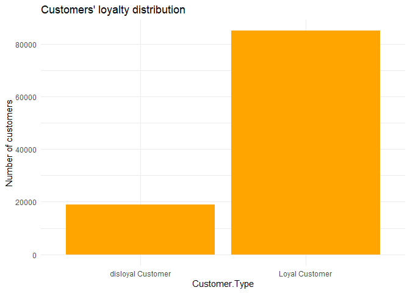

```r
ggplot(data = train, aes(x=Customer.Type))+ geom_bar(fill='orange', stat = 'count')+
  labs(title = "Customers' loyalty distribution", y = 'Number of customers')+
  theme_minimal()
```

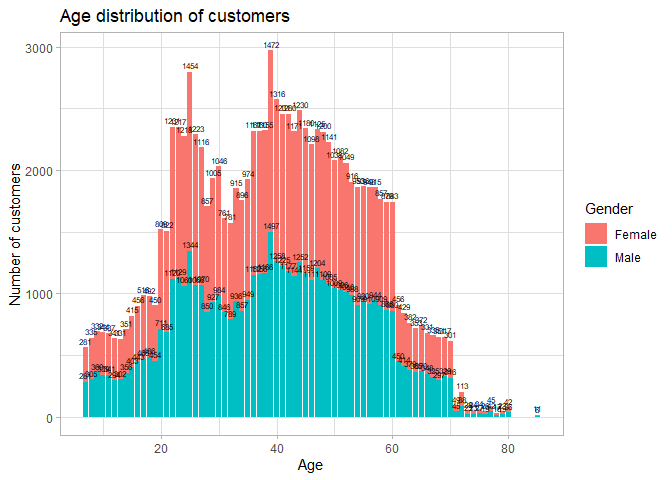

```r
ggplot(data = train, aes(x=Age, fill = Gender))+ geom_bar(stat = 'count', position = 'stack')+
  labs(title = 'Age distribution of customers', y = 'Number of customers')+
  geom_text(stat= 'count', aes(label=..count..),size = 2.0,vjust = - 0.5, position = 'stack')+
  theme_light()
```

```r
train %>%distinct(Type.of.Travel)
```

```
##    Type.of.Travel
## 1 Personal Travel
## 2 Business travel
```

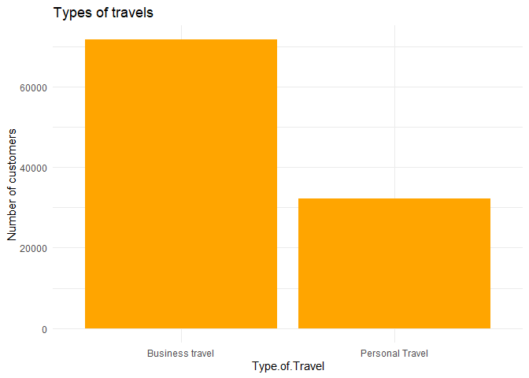

```r
ggplot(data = train, aes(x=Type.of.Travel))+ geom_bar(fill='orange', stat = 'count')+
  labs(title = 'Types of travels', y = 'Number of customers')+
  theme_minimal()
```

```r
train %>%distinct(Class)
```

```
##      Class
## 1 Eco Plus
## 2 Business
## 3      Eco
```

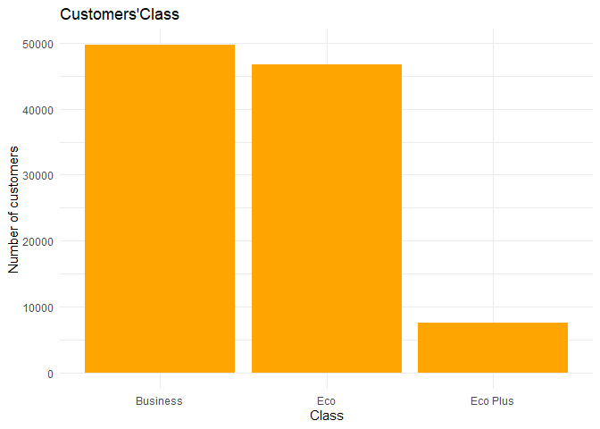

```r
ggplot(data = train, aes(x=Class))+ geom_bar(fill='orange', stat = 'count')+
  labs(title = "Customers'Class", y = 'Number of customers')+
  theme_minimal()
```

```r
train %>%distinct(satisfaction)
```

```
##              satisfaction
## 1 neutral or dissatisfied
## 2               satisfied
```

```r
train %>% count(satisfaction)
```

```
##              satisfaction     n
## 1 neutral or dissatisfied 58879
## 2               satisfied 45025
```

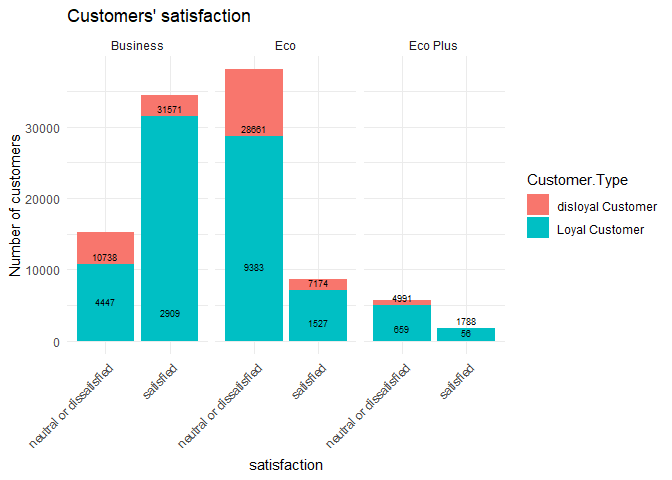

```r
ggplot(data = train, aes(x=satisfaction, fill = Customer.Type))+ geom_bar(stat = 'count')+
  facet_wrap(~ Class)+
  labs(title = "Customers' satisfaction", y = 'Number of customers')+
  geom_text(stat= 'count', aes(label=..count..),size = 2.4,vjust = - 0.5, position = 'dodge')+
  theme_minimal()+
  theme(axis.text.x = element_text(angle = 45, hjust = 1))
```

From the output above, we can conclude that:

- There is no wrong data in the columns explored
- The vast majority of the customers considered are loyal customers and business travellers
- The population gender is equally distributed (half male and half female), while Age follows a normal distribution. Hence, **Gender and Age will likely not play a significant role in profiling clusters**
- The most popular type of flight are Business and Eco. While customers of business class are generally satisfied, **there is a significant problem of customer satisfaction in Eco and Eco Plus classes**

To conclude this part, let’s get rid of the NA values and have a table that highlights the satisfaction problem just quoted:

```r
train_cleaned <- train %>% na.omit(Arrival.Delay.in.Minutes)

train_cleaned %>% group_by(Class) %>%
  summarise(LoyalCustomer= sum(Customer.Type == 'Loyal Customer'),
            DisloyalCustomer = sum(Customer.Type == 'disloyal Customer'),
            SatisfiedCustomer = percent(sum(satisfaction == "satisfied")/(LoyalCustomer + DisloyalCustomer)),
            Personal_travel = sum(Type.of.Travel == 'Personal Travel'),
            Business_travel = sum(Type.of.Travel == 'Business travel')) %>% knitr::kable()
```

| Class | LoyalCustomer | DisloyalCustomer | SatisfiedCustomer | Personal_travel | Business_travel |
| --- | --- | --- | --- | --- | --- |
| Business | 42191 | 7342 | 69% | 2149 | 47384 |
| Eco | 35716 | 10877 | 19% | 26391 | 20202 |
| Eco Plus | 6755 | 713 | 25% | 3589 | 3879 |

# BIVARIATE ANALYSIS: Contingency tables and ANOVA

Let’s now deep dive into the problem of satisfaction, asking two main questions:

- Do the qualitative data have an impact on satisfaction? (namely, is there a correlation between satisfaction and, for example, being a business traveller or a loyal customer?)
- Which are the most impactful drivers of satisfaction among our scalar values? (namely, is food and drink service that makes customers satisfied, or is it the wi-fi?)

## Contingency tables

```r
con1 <- table(train_cleaned$Class, train_cleaned$Customer.Type)#Business are loyal, problem is eco and ecoplus
knitr::kable(con1)
```

|  | disloyal Customer | Loyal Customer |
| --- | --- | --- |
| Business | 7342 | 42191 |
| Eco | 10877 | 35716 |
| Eco Plus | 713 | 6755 |

```r
chisq.test(con1)
```

```
##
##  Pearson's Chi-squared test
##
## data:  con1
## X-squared = 1578, df = 2, p-value < 2.2e-16
```

```r
cramer_v(con1)   ##0.1234206
```

```
## [1] 0.1234206
```

```r
con2 <- table(train_cleaned$Customer.Type, train_cleaned$satisfaction)  ##loyal customers are not satisfied: no strong correlation between loyalty and satisfaction
knitr::kable(con2)
```

|  | neutral or dissatisfied | satisfied |
| --- | --- | --- |
| disloyal Customer | 14448 | 4484 |
| Loyal Customer | 44249 | 40413 |

```r
chisq.test(con2)
```

```
##
##  Pearson's Chi-squared test with Yates' continuity correction
##
## data:  con2
## X-squared = 3643.3, df = 1, p-value < 2.2e-16
```

```r
cramer_v(con2)  ##0.1875332
```

```
## [1] 0.1875332
```

```r
con3 <- table(train_cleaned$Type.of.Travel, train_cleaned$satisfaction) ##58,26% of Business travelers are satisfied, while 89,84% of Personal are not satisfied
knitr::kable(con3)
```

|  | neutral or dissatisfied | satisfied |
| --- | --- | --- |
| Business travel | 29831 | 41634 |
| Personal Travel | 28866 | 3263 |

```r
chisq.test(con3)
```

```
##
##  Pearson's Chi-squared test with Yates' continuity correction
##
## data:  con3
## X-squared = 20882, df = 1, p-value < 2.2e-16
```

```r
cramer_v(con3)  ##0.4489738
```

```
## [1] 0.4489738
```

```r
con4 <- table(train_cleaned$Class, train_cleaned$satisfaction)  ##eco and eco plus are not satisfied
knitr::kable(con4)
```

|  | neutral or dissatisfied | satisfied |
| --- | --- | --- |
| Business | 15143 | 34390 |
| Eco | 37922 | 8671 |
| Eco Plus | 5632 | 1836 |

```r
chisq.test(con4)
```

```
##
##  Pearson's Chi-squared test
##
## data:  con4
## X-squared = 26402, df = 2, p-value < 2.2e-16
```

```r
cramer_v(con4)   ## 0.504839
```

```
## [1] 0.504839
```

From the output, we can conclude that:

- While every table is statistically significant (p.value < 0.05), **loyalty doesn’t play a significant role in satisfaction**, as we may expect from common sense and marketing theory: while disloyal customers are generally not satisfied, loyal ones are almost equally divided between satisfied and not satisfied
- Type of traveller and flight class play the most significant role, with a cramer value > 0.4. Hence, the solution of customer satisfaction will likely be found examining them.

## Means and ANOVA

```r
Diff_means <- train_cleaned %>% group_by(Type.of.Travel, satisfaction) %>%
  summarise(Inflight.wifi.service = mean(Inflight.wifi.service),
            Gate.location = mean(Gate.location),
            Departure.Arrival.time.convenient = mean(Departure.Arrival.time.convenient),
            Ease.of.Online.booking = mean(Ease.of.Online.booking),
            Food.and.drink = mean(Food.and.drink),
            Online.boarding = mean(Online.boarding),
            Seat.comfort = mean(Seat.comfort),
            Inflight.entertainment = mean(Inflight.entertainment),
            On.board.service = mean(On.board.service),
            Leg.room.service = mean(Leg.room.service),
            Baggage.handling = mean(Baggage.handling),
            Checkin.service = mean(Checkin.service),
            Inflight.service = mean(Inflight.service),
            Cleanliness = mean(Cleanliness))

Diff_means_eco <- train_cleaned %>% filter(Class == "Eco") %>%  group_by(satisfaction) %>%
  summarise(Inflight.wifi.service = mean(Inflight.wifi.service),
            Gate.location = mean(Gate.location),
            Departure.Arrival.time.convenient = mean(Departure.Arrival.time.convenient),
            Ease.of.Online.booking = mean(Ease.of.Online.booking),
            Food.and.drink = mean(Food.and.drink),
            Online.boarding = mean(Online.boarding),
            Seat.comfort = mean(Seat.comfort),
            Inflight.entertainment = mean(Inflight.entertainment),
            On.board.service = mean(On.board.service),
            Leg.room.service = mean(Leg.room.service),
            Baggage.handling = mean(Baggage.handling),
            Checkin.service = mean(Checkin.service),
            Inflight.service = mean(Inflight.service),
            Cleanliness = mean(Cleanliness))

calc_diff_business <- function(x) {
  return(abs(x[1] - x[2]))
}

calc_diff_personal <- function(x) {
  return(abs(x[3] - x[4]))
}

new_row_business <- data.frame(t(data.frame(c("Business travel", "Sat-neutr/dissat",apply(Diff_means[3:16], 2, calc_diff_business)))))

new_row_personal <- data.frame(t(data.frame(c("Personal Travel", "Sat-neutr/dissat",apply(Diff_means[3:16], 2, calc_diff_personal)))))

names(new_row_business) <- names(Diff_means)
names(new_row_personal) <- names(Diff_means)

new_row_business <- new_row_business %>% mutate_at(vars(3:16), as.numeric)
new_row_personal <- new_row_personal %>% mutate_at(vars(3:16), as.numeric)


Diff_means <- rbind(Diff_means, new_row_business, new_row_personal)
knitr::kable(Diff_means)%>%
   kableExtra::scroll_box(width = "800px", height = "600px")
```

| Type.of.Travel | satisfaction | Inflight.wifi.service | Gate.location | Departure.Arrival.time.convenient | Ease.of.Online.booking | Food.and.drink | Online.boarding | Seat.comfort | Inflight.entertainment | On.board.service | Leg.room.service | Baggage.handling | Checkin.service | Inflight.service | Cleanliness |
| --- | --- | --- | --- | --- | --- | --- | --- | --- | --- | --- | --- | --- | --- | --- | --- |
| Business travel | neutral or dissatisfied | 2.3997184 | 3.0297006 | 2.6261272 | 2.7181456 | 2.8475411 | 2.5977339 | 2.8849184 | 2.7273642 | 2.7711776 | 2.9265194 | 3.1812209 | 2.7598136 | 3.1847407 | 2.7461030 |
| Business travel | satisfied | 3.1265072 | 2.9845799 | 2.9149013 | 2.9995917 | 3.5527694 | 4.0670606 | 4.0255320 | 4.0374694 | 3.9044291 | 3.8657828 | 3.9970697 | 3.6696450 | 3.9979344 | 3.7924773 |
| Personal Travel | neutral or dissatisfied | 2.3997783 | 2.9215686 | 3.6488256 | 2.3704358 | 3.0728885 | 2.7168988 | 3.1943116 | 3.0664103 | 3.2757223 | 3.0578535 | 3.5766992 | 3.3361394 | 3.6001178 | 3.1328899 |
| Personal Travel | satisfied | 3.6037389 | 2.8896721 | 3.6714680 | 3.4361017 | 3.1130861 | 3.5197671 | 3.2096230 | 3.0441312 | 3.2598835 | 3.2693840 | 3.5743181 | 3.3395648 | 3.6120135 | 3.1265706 |
| Business travel | Sat-neutr/dissat | 0.7267888 | 0.0451207 | 0.2887741 | 0.2814461 | 0.7052282 | 1.4693267 | 1.1406136 | 1.3101052 | 1.1332514 | 0.9392634 | 0.8158488 | 0.9098314 | 0.8131937 | 1.0463743 |
| Personal Travel | Sat-neutr/dissat | 1.2039606 | 0.0318965 | 0.0226424 | 1.0656659 | 0.0401976 | 0.8028683 | 0.0153114 | 0.0222791 | 0.0158388 | 0.2115305 | 0.0023811 | 0.0034254 | 0.0118957 | 0.0063193 |

```r
write_xlsx(Diff_means, path = "Diff_means.xlsx")
```

Let’s now perform an ANOVA test in order to get the significance of these results and the correlation values with eta squared. Let’s first divide the two type of travellers

```r
Business <- train_cleaned %>% filter(Type.of.Travel == "Business travel")
Personal <- train_cleaned %>% filter(Type.of.Travel == "Personal Travel")
```

Let’s start from Business travellers:

```r
aov1 <- aov(Online.boarding ~ satisfaction, data = Business)
eta_squared(aov1)
```

```
## satisfaction
##    0.3078734
```

```r
anova(aov1)
```

```
## Analysis of Variance Table
##
## Response: Online.boarding
##                 Df Sum Sq Mean Sq F value    Pr(>F)
## satisfaction     1  37520   37520   31788 < 2.2e-16 ***
## Residuals    71463  84348       1
## ---
## Signif. codes:  0 '***' 0.001 '**' 0.01 '*' 0.05 '.' 0.1 ' ' 1
```

```r
aov2 <- aov(Seat.comfort ~ satisfaction, data = Business)
eta_squared(aov2)
```

```
## satisfaction
##    0.1944278
```

```r
anova(aov2)
```

```
## Analysis of Variance Table
##
## Response: Seat.comfort
##                 Df Sum Sq Mean Sq F value    Pr(>F)
## satisfaction     1  22610 22610.0   17248 < 2.2e-16 ***
## Residuals    71463  93680     1.3
## ---
## Signif. codes:  0 '***' 0.001 '**' 0.01 '*' 0.05 '.' 0.1 ' ' 1
```

```r
aov3 <- aov(Inflight.entertainment ~ satisfaction, data = Business)
eta_squared(aov3)
```

```
## satisfaction
##    0.2514648
```

```r
anova(aov3)
```

```
## Analysis of Variance Table
##
## Response: Inflight.entertainment
##                 Df Sum Sq Mean Sq F value    Pr(>F)
## satisfaction     1  29829 29828.7   24007 < 2.2e-16 ***
## Residuals    71463  88791     1.2
## ---
## Signif. codes:  0 '***' 0.001 '**' 0.01 '*' 0.05 '.' 0.1 ' ' 1
```

```r
aov4 <- aov(On.board.service ~ satisfaction, data = Business)
eta_squared(aov4)
```

```
## satisfaction
##    0.1902311
```

```r
anova(aov4)
```

```
## Analysis of Variance Table
##
## Response: On.board.service
##                 Df Sum Sq Mean Sq F value    Pr(>F)
## satisfaction     1  22319 22319.0   16788 < 2.2e-16 ***
## Residuals    71463  95007     1.3
## ---
## Signif. codes:  0 '***' 0.001 '**' 0.01 '*' 0.05 '.' 0.1 ' ' 1
```

```r
aov5 <- aov(Food.and.drink ~ satisfaction, data = Business)
eta_squared(aov5)
```

```
## satisfaction
##   0.07048743
```

```r
anova(aov5)
```

```
## Analysis of Variance Table
##
## Response: Food.and.drink
##                 Df Sum Sq Mean Sq F value    Pr(>F)
## satisfaction     1   8643  8643.3  5419.2 < 2.2e-16 ***
## Residuals    71463 113979     1.6
## ---
## Signif. codes:  0 '***' 0.001 '**' 0.01 '*' 0.05 '.' 0.1 ' ' 1
```

```r
aov6 <- aov(Baggage.handling ~ satisfaction, data = Business)
eta_squared(aov6)
```

```
## satisfaction
##    0.1212158
```

```r
anova(aov6)
```

```
## Analysis of Variance Table
##
## Response: Baggage.handling
##                 Df Sum Sq Mean Sq F value    Pr(>F)
## satisfaction     1  11568 11567.6  9857.3 < 2.2e-16 ***
## Residuals    71463  83862     1.2
## ---
## Signif. codes:  0 '***' 0.001 '**' 0.01 '*' 0.05 '.' 0.1 ' ' 1
```

```r
aov7 <- aov(Ease.of.Online.booking ~ satisfaction, data = Business)
eta_squared(aov7)
```

```
## satisfaction
##  0.009216908
```

```r
anova(aov7)
```

```
## Analysis of Variance Table
##
## Response: Ease.of.Online.booking
##                 Df Sum Sq Mean Sq F value    Pr(>F)
## satisfaction     1   1377 1376.62   664.8 < 2.2e-16 ***
## Residuals    71463 147981    2.07
## ---
## Signif. codes:  0 '***' 0.001 '**' 0.01 '*' 0.05 '.' 0.1 ' ' 1
```

All values are significant. As we have seen from the differences in means, Online boarding has the stronger correlation with satisfaction (medium one: > 0.3), while also inflight entertainment plays a considerable role (> 0,2)

Let’s now do an ANOVA test of the most significant drivers for Personal travellers:

```r
aov8 <- aov(Ease.of.Online.booking ~ satisfaction, data = Personal)
eta_squared(aov8)
```

```
## satisfaction
##   0.06689624
```

```r
anova(aov8)
```

```
## Analysis of Variance Table
##
## Response: Ease.of.Online.booking
##                 Df Sum Sq Mean Sq F value    Pr(>F)
## satisfaction     1   3329  3329.3  2303.3 < 2.2e-16 ***
## Residuals    32127  46438     1.4
## ---
## Signif. codes:  0 '***' 0.001 '**' 0.01 '*' 0.05 '.' 0.1 ' ' 1
```

```r
aov9 <- aov(Online.boarding ~ satisfaction, data = Personal)
eta_squared(aov9)
```

```
## satisfaction
##   0.03300533
```

```r
anova(aov9)
```

```
## Analysis of Variance Table
##
## Response: Online.boarding
##                 Df Sum Sq Mean Sq F value    Pr(>F)
## satisfaction     1   1890 1889.71  1096.6 < 2.2e-16 ***
## Residuals    32127  55365    1.72
## ---
## Signif. codes:  0 '***' 0.001 '**' 0.01 '*' 0.05 '.' 0.1 ' ' 1
```

```r
aov10 <- aov(Inflight.wifi.service ~ satisfaction, data = Personal)
eta_squared(aov10)
```

```
## satisfaction
##    0.1025873
```

```r
anova(aov10)
```

```
## Analysis of Variance Table
##
## Response: Inflight.wifi.service
##                 Df Sum Sq Mean Sq F value    Pr(>F)
## satisfaction     1   4249  4249.4  3672.6 < 2.2e-16 ***
## Residuals    32127  37173     1.2
## ---
## Signif. codes:  0 '***' 0.001 '**' 0.01 '*' 0.05 '.' 0.1 ' ' 1
```

As we can see, the eta values for this drivers are sensibly lower than the business ones. This means that Personal travellers are more difficult to satisfy, since multiple factors occur and interact among them. Let’s now conclude with the Eco class means:

```r
Eco <- train_cleaned %>% filter(Class == "Eco")

aov11 <- aov(Inflight.wifi.service ~ satisfaction, data = Eco)
TukeyHSD(aov11)
```

```
##   Tukey multiple comparisons of means
##     95% family-wise confidence level
##
## Fit: aov(formula = Inflight.wifi.service ~ satisfaction, data = Eco)
##
## $satisfaction
##                                      diff      lwr      upr p adj
## satisfied-neutral or dissatisfied 1.46576 1.440619 1.490901     0
```

```r
eta_squared(aov11)
```

```
## satisfaction
##    0.2189055
```

```r
anova(aov11)
```

```
## Analysis of Variance Table
##
## Response: Inflight.wifi.service
##                 Df Sum Sq Mean Sq F value    Pr(>F)
## satisfaction     1  15162 15162.3   13057 < 2.2e-16 ***
## Residuals    46591  54102     1.2
## ---
## Signif. codes:  0 '***' 0.001 '**' 0.01 '*' 0.05 '.' 0.1 ' ' 1
```

```r
aov12 <- aov(Online.boarding ~ satisfaction, data = Eco)
TukeyHSD(aov12)
```

```
##   Tukey multiple comparisons of means
##     95% family-wise confidence level
##
## Fit: aov(formula = Online.boarding ~ satisfaction, data = Eco)
##
## $satisfaction
##                                       diff     lwr      upr p adj
## satisfied-neutral or dissatisfied 1.069111 1.03994 1.098281     0
```

```r
eta_squared(aov12)
```

```
## satisfaction
##   0.09970764
```

```r
anova(aov12)
```

```
## Analysis of Variance Table
##
## Response: Online.boarding
##                 Df Sum Sq Mean Sq F value    Pr(>F)
## satisfaction     1   8067  8066.5    5160 < 2.2e-16 ***
## Residuals    46591  72835     1.6
## ---
## Signif. codes:  0 '***' 0.001 '**' 0.01 '*' 0.05 '.' 0.1 ' ' 1
```

As we can see, inflight wi-fi service plays the most significant role in Eco customers satisfaction

# EFA and CLUSTERING

Now that we have a clear vision on what would be key drivers for customer satisfaction, we need to reduce the complexity of our items in order to simplify clustering and group similar items under the same factor. Let’s start with the nScree() to see the suggested number of factor and asking for eigenvalues in order to decide the optimal number of factors. Making this decision, we need to respect some criteria:

- Number of factors = 30/40% of original items
- Total variance explained > 65%
- Communality > 20/30% for each item (since we are analyzing preferences)
- Interpretability of factors: they make sense

```r
nScree(train_cleaned[, 9:22])
```

```
##   noc naf nparallel nkaiser
## 1   4   1         4       4
```

```r
eigen(cor(train_cleaned[, 9:22]))$values
```

```
##  [1] 3.8002452 2.3618352 2.1661616 1.0633552 0.9509708 0.7001899 0.5401966
##  [8] 0.5146015 0.4692692 0.3683333 0.3285413 0.2951938 0.2531291 0.1879774
```

4 is the suggested number and, from the eigen values, we can see that 5 could be also a possible solution, since its eigen value is 0.95. Let’s now try three possible solutions:

```r
factanal(train_cleaned[, 9:22], factors = 5)
```

```
##
## Call:
## factanal(x = train_cleaned[, 9:22], factors = 5)
##
## Uniquenesses:
##             Inflight.wifi.service Departure.Arrival.time.convenient
##                             0.327                             0.553
##            Ease.of.Online.booking                     Gate.location
##                             0.190                             0.541
##                    Food.and.drink                   Online.boarding
##                             0.414                             0.322
##                      Seat.comfort            Inflight.entertainment
##                             0.337                             0.068
##                  On.board.service                  Leg.room.service
##                             0.494                             0.749
##                  Baggage.handling                   Checkin.service
##                             0.419                             0.696
##                  Inflight.service                       Cleanliness
##                             0.357                             0.269
##
## Loadings:
##                                   Factor1 Factor2 Factor3 Factor4 Factor5
## Inflight.wifi.service                      0.145   0.461   0.647  -0.110
## Departure.Arrival.time.convenient                  0.650           0.127
## Ease.of.Online.booking                             0.623   0.641
## Gate.location                                      0.672
## Food.and.drink                     0.763
## Online.boarding                    0.296                   0.716   0.270
## Seat.comfort                       0.764                   0.158   0.229
## Inflight.entertainment             0.806   0.500                  -0.160
## On.board.service                           0.694                   0.104
## Leg.room.service                           0.481           0.124
## Baggage.handling                           0.750                   0.121
## Checkin.service                    0.102   0.234                   0.485
## Inflight.service                           0.793                   0.101
## Cleanliness                        0.841                           0.124
##
##                Factor1 Factor2 Factor3 Factor4 Factor5
## SS loadings      2.647   2.245   1.483   1.410   0.479
## Proportion Var   0.189   0.160   0.106   0.101   0.034
## Cumulative Var   0.189   0.349   0.455   0.556   0.590
##
## Test of the hypothesis that 5 factors are sufficient.
## The chi square statistic is 5630.55 on 31 degrees of freedom.
## The p-value is 0
```

```r
factanal(train_cleaned[, 9:22], factors = 4)
```

```
##
## Call:
## factanal(x = train_cleaned[, 9:22], factors = 4)
##
## Uniquenesses:
##             Inflight.wifi.service Departure.Arrival.time.convenient
##                             0.361                             0.722
##            Ease.of.Online.booking                     Gate.location
##                             0.164                             0.655
##                    Food.and.drink                   Online.boarding
##                             0.387                             0.112
##                      Seat.comfort            Inflight.entertainment
##                             0.377                             0.173
##                  On.board.service                  Leg.room.service
##                             0.497                             0.753
##                  Baggage.handling                   Checkin.service
##                             0.418                             0.884
##                  Inflight.service                       Cleanliness
##                             0.352                             0.267
##
## Loadings:
##                                   Factor1 Factor2 Factor3 Factor4
## Inflight.wifi.service              0.114   0.127   0.715   0.314
## Departure.Arrival.time.convenient                  0.523
## Ease.of.Online.booking                             0.872   0.274
## Gate.location                                      0.573  -0.123
## Food.and.drink                     0.782
## Online.boarding                    0.268           0.192   0.877
## Seat.comfort                       0.747                   0.246
## Inflight.entertainment             0.778   0.468
## On.board.service                           0.700
## Leg.room.service                           0.481
## Baggage.handling                           0.761
## Checkin.service                            0.264           0.188
## Inflight.service                           0.804
## Cleanliness                        0.845                   0.113
##
##                Factor1 Factor2 Factor3 Factor4
## SS loadings      2.598   2.274   1.926   1.078
## Proportion Var   0.186   0.162   0.138   0.077
## Cumulative Var   0.186   0.348   0.486   0.563
##
## Test of the hypothesis that 4 factors are sufficient.
## The chi square statistic is 23041.7 on 41 degrees of freedom.
## The p-value is 0
```

```r
factanal(train_cleaned[, 9:22], factors = 3)
```

```
##
## Call:
## factanal(x = train_cleaned[, 9:22], factors = 3)
##
## Uniquenesses:
##             Inflight.wifi.service Departure.Arrival.time.convenient
##                             0.383                             0.777
##            Ease.of.Online.booking                     Gate.location
##                             0.117                             0.765
##                    Food.and.drink                   Online.boarding
##                             0.405                             0.681
##                      Seat.comfort            Inflight.entertainment
##                             0.395                             0.198
##                  On.board.service                  Leg.room.service
##                             0.505                             0.754
##                  Baggage.handling                   Checkin.service
##                             0.415                             0.916
##                  Inflight.service                       Cleanliness
##                             0.348                             0.255
##
## Loadings:
##                                   Factor1 Factor2 Factor3
## Inflight.wifi.service              0.145   0.127   0.762
## Departure.Arrival.time.convenient                  0.468
## Ease.of.Online.booking                             0.939
## Gate.location                                      0.484
## Food.and.drink                     0.770
## Online.boarding                    0.367           0.420
## Seat.comfort                       0.773
## Inflight.entertainment             0.755   0.479
## On.board.service                           0.697
## Leg.room.service                           0.480   0.101
## Baggage.handling                           0.764
## Checkin.service                    0.122   0.263
## Inflight.service                           0.807
## Cleanliness                        0.858
##
##                Factor1 Factor2 Factor3
## SS loadings      2.685   2.294   2.108
## Proportion Var   0.192   0.164   0.151
## Cumulative Var   0.192   0.356   0.506
##
## Test of the hypothesis that 3 factors are sufficient.
## The chi square statistic is 49967.92 on 52 degrees of freedom.
## The p-value is 0
```

FACTORS = 5:

PRO

- **Uniqueness values are good**: only two items have a unique variance not explained by factors > 0.6
- **Cumulative variance > 0.5**

CONS

- **Fifth factor is useless**: it explains 0.034 of the cumulative variance and it captures only one items, which seems to have more sense grouped in the second factor

FACTORS = 4:

PRO

- **Factors make sense**: factors are well grouped, with only one of them (Online boarding) left alone. The variance explained by each of them is proportioned
- **Cumulative variance > 0.5**

CONS

- **Uniqueness values are worse than previously**: four items are not explained for more than half of their variance

FACTORS = 3:

PRO

- **Factors make sense**: no item is left alone and factor are really easy to interpret
- **Best SS loading and proportion var values so far**: factors are almost equally important in explaining variance of items

CONS

- **Cumulative variance is 0.5**
- **Items are too simplified**: from 14 to 3, it seems a too strong reduction

For the considerations above, it seems that a good solution could be either 4 or 3 factors. Since 3 it seems to me a too strong reduction, I’ll opt for 4 as final solution.

```r
factanal(train_cleaned[, 9:22], factors = 4, rotation = 'promax', param = 1, scores = "Bartlett") ##equamax rotation explain a little bit less variance, but factor 4 has more sense
```

```
##
## Call:
## factanal(x = train_cleaned[, 9:22], factors = 4, scores = "Bartlett",     rotation = "promax", param = 1)
##
## Uniquenesses:
##             Inflight.wifi.service Departure.Arrival.time.convenient
##                             0.361                             0.722
##            Ease.of.Online.booking                     Gate.location
##                             0.164                             0.655
##                    Food.and.drink                   Online.boarding
##                             0.387                             0.112
##                      Seat.comfort            Inflight.entertainment
##                             0.377                             0.173
##                  On.board.service                  Leg.room.service
##                             0.497                             0.753
##                  Baggage.handling                   Checkin.service
##                             0.418                             0.884
##                  Inflight.service                       Cleanliness
##                             0.352                             0.267
##
## Loadings:
##                                   Factor1 Factor2 Factor3 Factor4
## Inflight.wifi.service                              0.727   0.209
## Departure.Arrival.time.convenient                  0.524  -0.124
## Ease.of.Online.booking                             0.894   0.158
## Gate.location                                      0.572  -0.228
## Food.and.drink                     0.830  -0.116
## Online.boarding                                    0.225   0.891
## Seat.comfort                       0.718                   0.184
## Inflight.entertainment             0.785   0.361
## On.board.service                           0.696
## Leg.room.service                           0.474
## Baggage.handling                           0.776
## Checkin.service                            0.234           0.196
## Inflight.service                           0.822
## Cleanliness                        0.863
##
##                Factor1 Factor2 Factor3 Factor4
## SS loadings      2.578   2.206   1.992   1.023
## Proportion Var   0.184   0.158   0.142   0.073
## Cumulative Var   0.184   0.342   0.484   0.557
##
## Factor Correlations:
##         Factor1 Factor2 Factor3 Factor4
## Factor1  1.0000  0.0932   0.252   0.406
## Factor2  0.0932  1.0000   0.112   0.127
## Factor3  0.2519  0.1122   1.000   0.223
## Factor4  0.4056  0.1267   0.223   1.000
##
## Test of the hypothesis that 4 factors are sufficient.
## The chi square statistic is 23041.7 on 41 degrees of freedom.
## The p-value is 0
```

```r
fa <- factanal(train_cleaned[, 9:22], factors = 4, rotation = 'promax', param = 1, scores = "Bartlett")

factor_scores <- data.frame(fa$scores)
```

Now it is time to interpret the four factors obtained, giving them a new name to make the following steps a little bit easier:

- Factor1 = food and drink + inflight entertainment + cleanliness + seat comfort —> this items represent the enjoyment aspect of the flight, therefore we can label the factor **“Enjoyment”**
- Factor2 = On.board.service + Leg.room.service + Baggage.handling + Checkin.service + Inflight.service —> this items represent the service aspect of the flight, therefore we can label the factor **“Service”**
- Factor3 = Inflight.wifi.service + Departure.Arrival.time.convenient + Ease.of.Online.booking + Gate.location —> this items represent the user-friendly aspect of the flight, therefore we can label the factor **“Ease_of_the_flight”**, meaning that it is easy to book and take because the customer journey is smooth. It combines the logistic aspect of the flight with the digital offer of it
- Factor4 = Online boarding –> the name will remain the same. We notice how well it would fit in the previous factor and that was the main pro aspect of the 3 factors solution.

```r
factor_scores <- factor_scores %>% rename("Enjoyment" = Factor1, "Service" = Factor2, "Ease_of_the_flight" = Factor3, "Online_Boarding" = Factor4)

final_df <- cbind(train_cleaned, factor_scores)
```

We can now proceed with cluster analysis

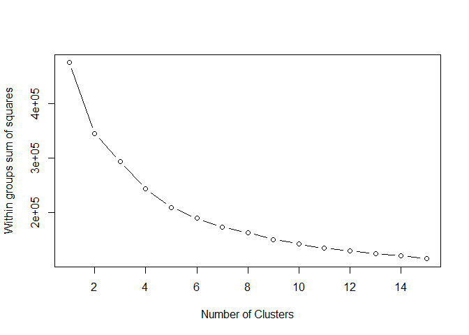

```
##  [1] 475914.8 345497.1 294056.9 243827.0 209501.5 189254.1 173258.4 163261.6
##  [9] 150004.4 142337.4 133923.3 129244.8 123692.5 120472.9 114768.0
```

```r
wssplot <- function(data, nc=15, seed=1234){
  wss <- (nrow(data)-1)*sum(apply(data,2,var))
  for (i in 2:nc){
    set.seed(seed)
    wss[i] <- sum(kmeans(data, centers=i)$withinss)}
  plot(1:nc, wss, type="b", xlab="Number of Clusters",
       ylab="Within groups sum of squares")
  wss
}  ## to obtain the ideal number of cluster for the k-mean clustering

wssplot(factor_scores)
```

We will try three different solutions, namely 4,5 and 6 clusters:

```r
kmeans(factor_scores, centers = 4)$centers
```

```
##     Enjoyment     Service Ease_of_the_flight Online_Boarding
## 1  0.51178596  0.09003957        -0.58256424      -1.2334644
## 2  0.63753305  0.81436163         0.28218819       0.8099307
## 3 -1.44126415 -0.12851439        -0.02908576      -0.7827344
## 4  0.03037664 -1.35171578        -0.03600302       0.3120876
```

```r
kmeans(factor_scores, centers = 4)$size
```

```
## [1] 22405 30374 33305 17510
```

```r
kmeans(factor_scores, centers = 5)$centers
```

```
##    Enjoyment     Service Ease_of_the_flight Online_Boarding
## 1  0.5153437  0.05971741        -0.64591533      -1.2642456
## 2  0.5331426  0.59558545         1.04072353       0.3913941
## 3 -0.1493761 -1.53102657        -0.05395311       0.1437049
## 4 -1.5503851 -0.13136775        -0.16286447      -0.8378973
## 5  0.6156017  0.69741686        -1.03056696       1.2836425
```

```r
kmeans(factor_scores, centers = 5)$size
```

```
## [1] 18791 15503 20905 31048 17347
```

```r
kmeans(factor_scores, centers = 6)$centers
```

```
##    Enjoyment     Service Ease_of_the_flight Online_Boarding
## 1  0.3152760 -0.77717075          0.7937323      0.05464958
## 2  0.4680450  0.08714003         -0.7105582     -1.30610243
## 3 -0.3880537 -1.90576628         -0.6877510      0.22386421
## 4  0.4993882  0.88378324          1.0142500      0.44772387
## 5 -1.5926888 -0.12923682         -0.2018274     -0.85992273
## 6  0.6216617  0.70023015         -1.0371977      1.28733515
```

```r
kmeans(factor_scores, centers = 6)$size
```

```
## [1] 17667 15079 16166 17143 24939 12600
```

```r
clus <- as.data.frame(kmeans(factor_scores, centers = 4)$cluster) %>%
  rename("clusters" = 'kmeans(factor_scores, centers = 4)$cluster')


k1 <- cbind(factor_scores, clus)


##test the significance of the clusters

anova(lm(Service ~ clusters, data = k1))  ##p.value = 0.3334
```

```
## Analysis of Variance Table
##
## Response: Service
##               Df Sum Sq Mean Sq F value    Pr(>F)
## clusters       1    297 297.271  251.38 < 2.2e-16 ***
## Residuals 103592 122504   1.183
## ---
## Signif. codes:  0 '***' 0.001 '**' 0.01 '*' 0.05 '.' 0.1 ' ' 1
```

```r
anova(lm(Enjoyment ~ clusters, data = k1))
```

```
## Analysis of Variance Table
##
## Response: Enjoyment
##               Df Sum Sq Mean Sq F value    Pr(>F)
## clusters       1  26167 26167.4   30623 < 2.2e-16 ***
## Residuals 103592  88520     0.9
## ---
## Signif. codes:  0 '***' 0.001 '**' 0.01 '*' 0.05 '.' 0.1 ' ' 1
```

```r
anova(lm(Ease_of_the_flight ~ clusters, data = k1))
```

```
## Analysis of Variance Table
##
## Response: Ease_of_the_flight
##               Df Sum Sq Mean Sq F value    Pr(>F)
## clusters       1  38929   38929   50293 < 2.2e-16 ***
## Residuals 103592  80185       1
## ---
## Signif. codes:  0 '***' 0.001 '**' 0.01 '*' 0.05 '.' 0.1 ' ' 1
```

```r
anova(lm(Online_Boarding ~ clusters, data = k1))
```

```
## Analysis of Variance Table
##
## Response: Online_Boarding
##               Df Sum Sq Mean Sq F value    Pr(>F)
## clusters       1  18774   18774   19344 < 2.2e-16 ***
## Residuals 103592 100538       1
## ---
## Signif. codes:  0 '***' 0.001 '**' 0.01 '*' 0.05 '.' 0.1 ' ' 1
```

In conclusion, we obtain the following clusters:

- Cluster1: it is mainly interested by enjoyment of the flight and doesn’t care about online boarding
- Cluster2: it is the most demanding cluster since it gives importance to all factors, especially online boarding and service
- Cluster3: it is indifferent to all factors, especially enjoyment
- Cluster4: it is mainly concerned with Online boarding and doesn’t care about services

## EXPLORATION OF CLUSTER OBTAINED

```r
final_Df <- cbind(train_cleaned, factor_scores, k1[5])


clus_info <- final_Df %>% filter(clusters != 3) %>% group_by(clusters) %>%
  summarize(Personal.traveller = sum(Type.of.Travel == "Personal Travel"),
            Business.traveller = sum(Type.of.Travel == "Business travel"),
            Personal.traveller.prc  = percent(Personal.traveller / (Personal.traveller + Business.traveller)),
            Business.traveller.prc = percent(Business.traveller / (Personal.traveller + Business.traveller)),
            Loyal = sum(Customer.Type == "Loyal Customer"),
            Disloyal = sum(Customer.Type == "disloyal Customer"),
            Loyal_prc = percent(Loyal/(Loyal + Disloyal)),
            Age = round(mean(Age), digits = 0),
            Eco = sum(Class == "Eco"),
            Eco.Plus = sum(Class == "Eco Plus"),
            Business = sum(Class == "Business"),
            Eco_prc = percent(Eco / (Eco + Eco.Plus+Business)),
            Eco.Plus_prc = percent(Eco.Plus / (Eco + Eco.Plus+Business)),
            Business_prc = percent(Business / (Eco + Eco.Plus+Business)),
            Flight.Distance = round(mean(Flight.Distance), digits = 0),
            Avrg_Delay = round(mean(Arrival.Delay.in.Minutes), digits = 0),
            Satisfied = sum(satisfaction == "satisfied"),
            Neutral.Dissatisfied = sum(satisfaction == "neutral or dissatisfied"),
            Satisfied_prc = percent(Satisfied / (Satisfied + Neutral.Dissatisfied)))

knitr::kable(clus_info)
```

| clusters | Personal.traveller | Business.traveller | Personal.traveller.prc | Business.traveller.prc | Loyal | Disloyal | Loyal_prc | Age | Eco | Eco.Plus | Business | Eco_prc | Eco.Plus_prc | Business_prc | Flight.Distance | Avrg_Delay | Satisfied | Neutral.Dissatisfied | Satisfied_prc |
| --- | --- | --- | --- | --- | --- | --- | --- | --- | --- | --- | --- | --- | --- | --- | --- | --- | --- | --- | --- |
| 1 | 8610 | 24695 | 26% | 74% | 27171 | 6134 | 82% | 39 | 12342 | 2003 | 18960 | 37% | 6% | 57% | 1264 | 13 | 21303 | 12002 | 64% |
| 2 | 7826 | 14570 | 35% | 65% | 18736 | 3660 | 84% | 42 | 12026 | 1913 | 8457 | 54% | 9% | 38% | 1117 | 16 | 4819 | 17577 | 22% |
| 4 | 13667 | 16714 | 45% | 55% | 21473 | 8908 | 71% | 34 | 19385 | 2880 | 8116 | 64% | 9% | 27% | 903 | 17 | 4110 | 26271 | 14% |

As we have already pointed out at the beginning of the analysis, the main problems of satisfaction lie in Personal travels, more precisely of Eco and Eco Plus flight classes. After our clustering, we now know that cluster 2 and 4 are the most problematic, since in cluster 1 are mainly business travellers and satisfied.

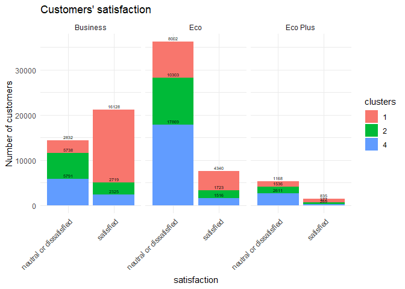

```r
final_Df$clusters <- as.character(final_Df$clusters)

final_Df <- final_Df %>% filter(clusters != "3")

ggplot(data = final_Df, aes(x=satisfaction, fill = clusters))+ geom_bar(stat = 'count')+
  facet_wrap(~ Class)+
  labs(title = "Customers' satisfaction", y = 'Number of customers')+
  geom_text(stat= 'count', aes(label=..count..),size = 1.8,vjust = - 0.5, position = 'stack')+
  theme_minimal()+
  theme(axis.text.x = element_text(angle = 45, hjust = 1))
```

## CONCLUSION

To increase customer satisfaction, the company need to work on Eco customers since they are the most unsatisfied. Considering ANOVA results and clustering, there are two ways of increasing their satisfaction: